# Time Series Analysis

Joe Eckert

October 15, 2015

### Question #1: ARIMA Modelling

```r
library(TSA)
```

```
## locfit 1.5-9.1    2013-03-22
##
##
```

```r
library(forecast)
library(tseries)

sig = function(model){

  return(round((1 - pnorm(abs(model$coef)/sqrt(diag(model$var.coef)))) * 2, 3))

}
```

For each of the listed datasets, follow the procedure below to fit an ARIMA model.

#### The hare dataset in the TSA library (load by calling data(hare)); this dataset describes the annual number of Canadian hare near the Hudson bay area.

```r
data(hare)
```

##### 1.Plot the original time series

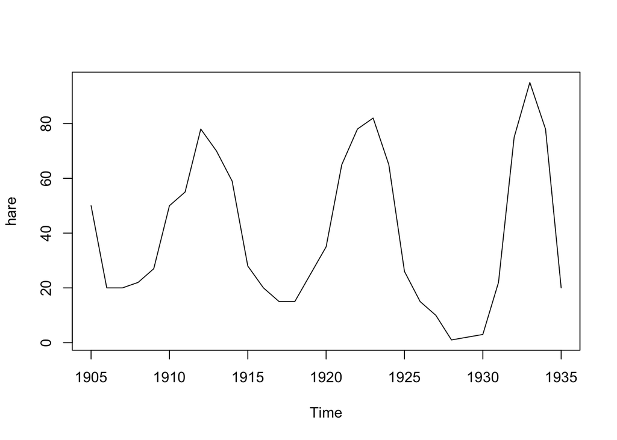

```r
plot(hare)
```

##### 2.Determine the estimated number of differences necessary to make the time series stationary. If non-stationary, plot the differenced time series.

```r
ndiffs(hare)
```

```
## [1] 0
```

d = 0

##### 3.Run the Augmented Dicky-Fuller test and interpret the results. If necessary, return to part 2.

```r
adf.test(hare)
```

```
##
##  Augmented Dickey-Fuller Test
##
## data:  hare
## Dickey-Fuller = -3.5051, Lag order = 3, p-value = 0.06064
## alternative hypothesis: stationary
```

Close enough to yielding a significant p-value; move forward without differencing.

##### 4.Plot the autocorrelation and partial autocorrelation functions to determine intial values of p & q.

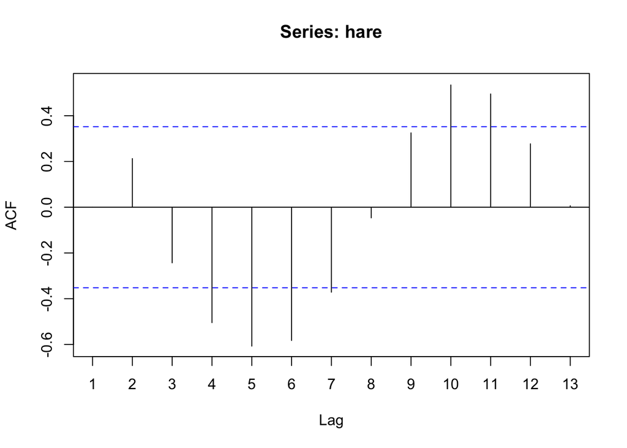

```r
Acf(hare)
```

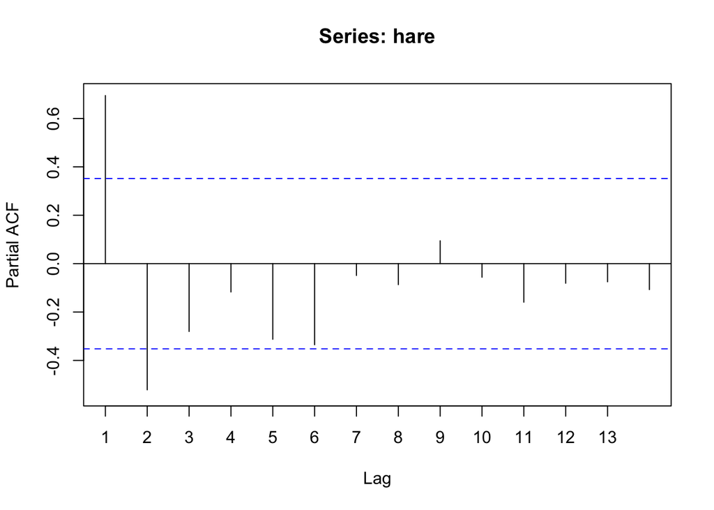

```r
Pacf(hare)
```

Let’s start with AR(2) and an MA(0); p = 2, q = 0 initially.

##### 5.Fit an initial ARIMA model.

```r
fit200 = Arima(hare, c(2, 0, 0))
summary(fit200)
```

```
## Series: hare
## ARIMA(2,0,0) with non-zero mean
##
## Coefficients:
##          ar1      ar2  intercept
##       1.3021  -0.7971    38.2165
## s.e.  0.1260   0.1203     4.9255
##
## sigma^2 estimated as 176.6:  log likelihood=-125.57
## AIC=259.13   AICc=260.67   BIC=264.87
##
## Training set error measures:
##                      ME     RMSE      MAE       MPE     MAPE      MASE
## Training set -0.3209189 13.29027 11.00366 -101.9961 128.6551 0.7053625
##                   ACF1
## Training set 0.1460072
```

```r
sig(fit200)
```

```
##       ar1       ar2 intercept
##         0         0         0
```

##### 6.Follow the process of overfitting the initial ARIMA model you fit in part 5. At each step, examine the Wald test statistics for the coefficient estimates. (NB: If you seem to have already overfit your model, try taking away terms by reversing the overfitting process).

```r
fit300 = Arima(hare, order = c(3, 0, 0))
summary(fit300)
```

```
## Series: hare
## ARIMA(3,0,0) with non-zero mean
##
## Coefficients:
##          ar1      ar2      ar3  intercept
##       1.0956  -0.4321  -0.2778    38.0405
## s.e.  0.1884   0.2846   0.1951     3.8841
##
## sigma^2 estimated as 164.5:  log likelihood=-124.6
## AIC=259.21   AICc=261.61   BIC=266.38
##
## Training set error measures:
##                      ME     RMSE      MAE       MPE     MAPE     MASE
## Training set -0.2025207 12.82769 10.23227 -108.5978 133.8589 0.655915
##                     ACF1
## Training set -0.01692516
```

```r
sig(fit300) #p = 3, coefficients are not significant, will use p = 2 and move onto q
```

```
##       ar1       ar2       ar3 intercept
##     0.000     0.129     0.155     0.000
```

```r
fit201 = Arima(hare, order = c(2, 0, 1))
summary(fit201)
```

```
## Series: hare
## ARIMA(2,0,1) with non-zero mean
##
## Coefficients:
##          ar1      ar2      ma1  intercept
##       1.4611  -0.8869  -0.4754    38.2355
## s.e.  0.1029   0.0792   0.2833     3.0063
##
## sigma^2 estimated as 163.3:  log likelihood=-124.41
## AIC=258.83   AICc=261.23   BIC=266
##
## Training set error measures:
##                     ME    RMSE      MAE       MPE     MAPE      MASE
## Training set -0.135055 12.7778 10.11183 -100.4416 125.8358 0.6481941
##                    ACF1
## Training set 0.01174678
```

```r
sig(fit201) #ma term is not significant, however it is low enough we will leave it an add another ar term
```

```
##       ar1       ar2       ma1 intercept
##     0.000     0.000     0.093     0.000
```

```r
fit301 = Arima(hare, order = c(3, 0, 1))
summary(fit301)
```

```
## Series: hare
## ARIMA(3,0,1) with non-zero mean
##
## Coefficients:
##          ar1      ar2     ar3      ma1  intercept
##       1.6625  -1.1762  0.1887  -0.6411    38.3842
## s.e.  0.3716   0.5401  0.3514   0.3204     2.7516
##
## sigma^2 estimated as 162.2:  log likelihood=-124.28
## AIC=260.55   AICc=264.05   BIC=269.15
##
## Training set error measures:
##                     ME     RMSE      MAE       MPE     MAPE      MASE
## Training set -0.075815 12.73495 10.13106 -96.87555 122.0449 0.6494271
##                    ACF1
## Training set 0.07588914
```

```r
sig(fit301) #third ar term is not significant, so we dont want to add the third ar term, try another ma term
```

```
##       ar1       ar2       ar3       ma1 intercept
##     0.000     0.029     0.591     0.045     0.000
```

```r
fit202 = Arima(hare, order = c(2, 0, 2))
summary(fit202)
```

```
## Series: hare
## ARIMA(2,0,2) with non-zero mean
##
## Coefficients:
##          ar1      ar2      ma1      ma2  intercept
##       1.4558  -0.8709  -0.4517  -0.0800    38.3503
## s.e.  0.0995   0.0934   0.2321   0.1837     2.7922
##
## sigma^2 estimated as 162.6:  log likelihood=-124.32
## AIC=260.63   AICc=264.13   BIC=269.23
##
## Training set error measures:
##                       ME     RMSE     MAE       MPE     MAPE      MASE
## Training set -0.09963619 12.75073 10.0791 -96.88033 121.8773 0.6460963
##                    ACF1
## Training set 0.06292876
```

```r
sig(fit202) #2nd ma term is not significant, revert back to fit201
```

```
##       ar1       ar2       ma1       ma2 intercept
##     0.000     0.000     0.052     0.663     0.000
```

##### 7.Evaluate the family of models you created in part 6 and select the best (examine the AIC, BIC, and RMSE).

```r
AIC(fit200, fit300, fit201)
```

```
##        df      AIC
## fit200  4 259.1327
## fit300  5 259.2098
## fit201  5 258.8292
```

```r
BIC(fit200, fit300, fit201)
```

```
##        df      BIC
## fit200  4 264.8687
## fit300  5 266.3797
## fit201  5 265.9991
```

```r
summary(fit200) #RMSE 13.29
```

```
## Series: hare
## ARIMA(2,0,0) with non-zero mean
##
## Coefficients:
##          ar1      ar2  intercept
##       1.3021  -0.7971    38.2165
## s.e.  0.1260   0.1203     4.9255
##
## sigma^2 estimated as 176.6:  log likelihood=-125.57
## AIC=259.13   AICc=260.67   BIC=264.87
##
## Training set error measures:
##                      ME     RMSE      MAE       MPE     MAPE      MASE
## Training set -0.3209189 13.29027 11.00366 -101.9961 128.6551 0.7053625
##                   ACF1
## Training set 0.1460072
```

```r
summary(fit300) #RMSE 12.83
```

```
## Series: hare
## ARIMA(3,0,0) with non-zero mean
##
## Coefficients:
##          ar1      ar2      ar3  intercept
##       1.0956  -0.4321  -0.2778    38.0405
## s.e.  0.1884   0.2846   0.1951     3.8841
##
## sigma^2 estimated as 164.5:  log likelihood=-124.6
## AIC=259.21   AICc=261.61   BIC=266.38
##
## Training set error measures:
##                      ME     RMSE      MAE       MPE     MAPE     MASE
## Training set -0.2025207 12.82769 10.23227 -108.5978 133.8589 0.655915
##                     ACF1
## Training set -0.01692516
```

```r
summary(fit201) #RMSE 12.78
```

```
## Series: hare
## ARIMA(2,0,1) with non-zero mean
##
## Coefficients:
##          ar1      ar2      ma1  intercept
##       1.4611  -0.8869  -0.4754    38.2355
## s.e.  0.1029   0.0792   0.2833     3.0063
##
## sigma^2 estimated as 163.3:  log likelihood=-124.41
## AIC=258.83   AICc=261.23   BIC=266
##
## Training set error measures:
##                     ME    RMSE      MAE       MPE     MAPE      MASE
## Training set -0.135055 12.7778 10.11183 -100.4416 125.8358 0.6481941
##                    ACF1
## Training set 0.01174678
```

Everything is similar, we will choose the most parsimonious model (fit200).

##### 8.Loosely interpret the coefficient estimates of the model you selected in part 7.

```r
fit200$coef
```

```
##        ar1        ar2  intercept
##  1.3021459 -0.7971434 38.2164994
```

The intercept is 38, this means that the data averages around 38. The ar1 coefficient of 1.3 means that the t-1 value impacts the current value by 1.3x, and the t-2 value impacts the current value by -.79.

##### 9. Perform diagnostic tests for the best model by assessing:

###### a. The constant variance assumption (graphically).

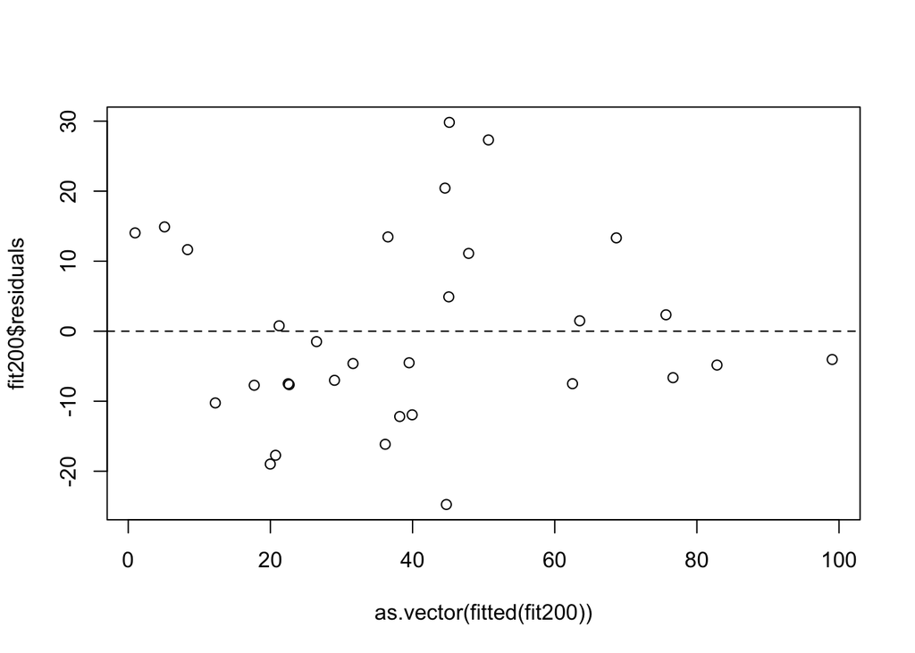

```r
plot(as.vector(fitted(fit200)), fit200$residuals)
abline(h = 0, lty = 2)
```

Maybe a violation of constant variance, not clear.

###### b. The normality assumption (graphically).

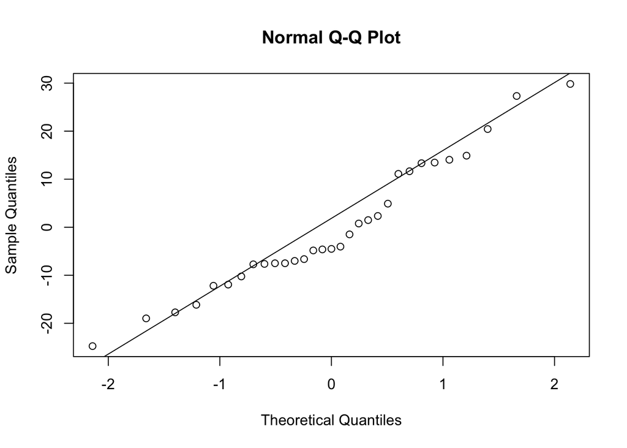

```r
qqnorm(fit200$residuals)
qqline(fit200$residuals)
```

Might be an issue as well.

###### c. The independence assumption (graphically & statistically).

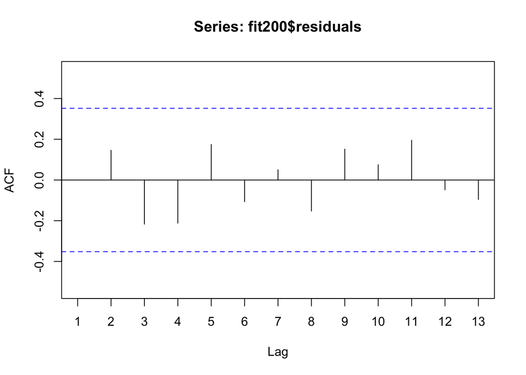

```r
Acf(fit200$residuals) #nothing significant here, independence is okay
```

```r
Box.test(fit200$residuals, type = "Ljung-Box") #p-value is insignificant therefore we can retain the null hypothesis that the correlations among the residuals are zero, therefore the model is sufficient.
```

```
##
##  Box-Ljung test
##
## data:  fit200$residuals
## X-squared = 1.2273, df = 1, p-value = 0.2679
```

##### 10. Forecast the next few observations and display this graphically.

```r
new.values <- forecast(fit200, 10, level = c(60, 80, 95))
new.values
```

```
##      Point Forecast      Lo 60     Hi 60       Lo 80      Hi 80      Lo 95
## 1936     -17.217196 -28.402573 -6.031819 -34.2493675  -0.185024 -43.265655
## 1937     -19.445100 -37.809514 -1.080687 -47.4089183   8.518718 -62.212069
## 1938       7.321284 -13.612948 28.255517 -24.5556421  39.198211 -41.430268
## 1939      43.950983  22.964824 64.937142  11.9949867  75.906979  -4.921496
## 1940      70.311550  48.459720 92.163381  37.0373809 103.585720  19.423100
## 1941      75.437734  51.764625 99.110843  39.3902715 111.485197  20.307898
## 1942      61.099622  36.412522 85.786722  23.5081378  98.691106   3.608408
## 1943      38.343004  13.585942 63.100066   0.6449864  76.041021 -19.311139
## 1944      20.140097  -4.817852 45.098046 -17.8638140  58.144008 -37.981869
## 1945      14.577543 -11.000444 40.155529 -24.3705104  53.525596 -44.988364
##           Hi 95
## 1936   8.831263
## 1937  23.321869
## 1938  56.072837
## 1939  92.823462
## 1940 121.200001
## 1941 130.567571
## 1942 118.590836
## 1943  95.997146
## 1944  78.262063
## 1945  74.143450
```

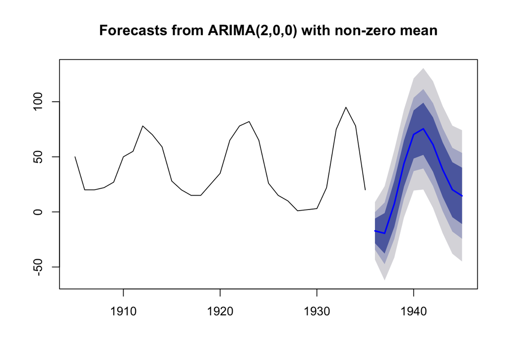

```r
plot(new.values)
```

Be careful to note that it’s predicting negative values, which is not possible.

##### 11. How will the Canadian hare population change over time?

The model shows that the seasonality continues with an initial drop in population and then a spike in 1940.

#### The WWWusage dataset; this dataset describes internet usage by logging the number of users connected to a server every minute.

```r
WWWusage
```

```
## Time Series:
## Start = 1
## End = 100
## Frequency = 1
##   [1]  88  84  85  85  84  85  83  85  88  89  91  99 104 112 126 138 146
##  [18] 151 150 148 147 149 143 132 131 139 147 150 148 145 140 134 131 131
##  [35] 129 126 126 132 137 140 142 150 159 167 170 171 172 172 174 175 172
##  [52] 172 174 174 169 165 156 142 131 121 112 104 102  99  99  95  88  84
##  [69]  84  87  89  88  85  86  89  91  91  94 101 110 121 135 145 149 156
##  [86] 165 171 175 177 182 193 204 208 210 215 222 228 226 222 220
```

##### 1.Plot the original time series

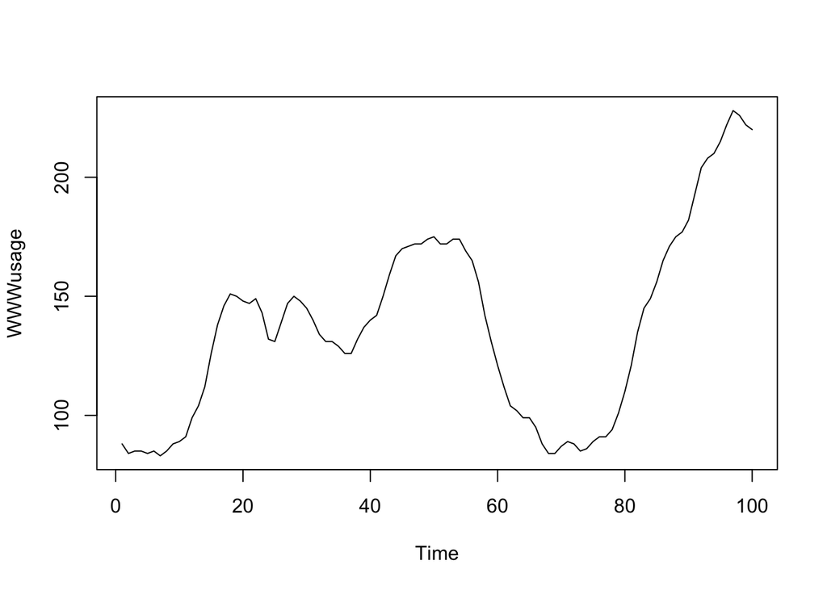

```r
plot(WWWusage)
```

##### 2.Determine the estimated number of differences necessary to make the time series stationary. If non-stationary, plot the differenced time series.

```r
ndiffs(WWWusage)
```

```
## [1] 1
```

```r
WWWusageDif <- diff(WWWusage, differences = 1)
ndiffs(WWWusageDif)
```

```
## [1] 0
```

d = 1 Differencing once results in ndiffs = 0

##### 3.Run the Augmented Dicky-Fuller test and interpret the results. If necessary, return to part 2.

```r
adf.test(WWWusageDif)
```

```
##
##  Augmented Dickey-Fuller Test
##
## data:  WWWusageDif
## Dickey-Fuller = -2.5459, Lag order = 4, p-value = 0.3506
## alternative hypothesis: stationary
```

```r
WWWusageDif2 <- diff(WWWusageDif, differences = 1)
adf.test(WWWusageDif2)
```

```
##
##  Augmented Dickey-Fuller Test
##
## data:  WWWusageDif2
## Dickey-Fuller = -4.828, Lag order = 4, p-value = 0.01
## alternative hypothesis: stationary
```

The p-value is .35 and not significant therefore the differenced model is not stationary. I will re do the difference again and test the adf.

The second differenced model results in a significant p value of .01, therefore we will use this model going forward.

##### 4.Plot the autocorrelation and partial autocorrelation functions to determine intial values of p & q.

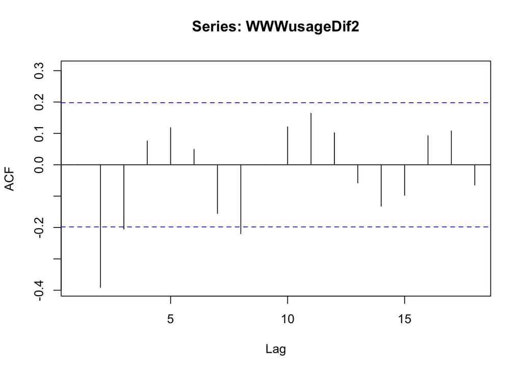

```r
Acf(WWWusageDif2)
```

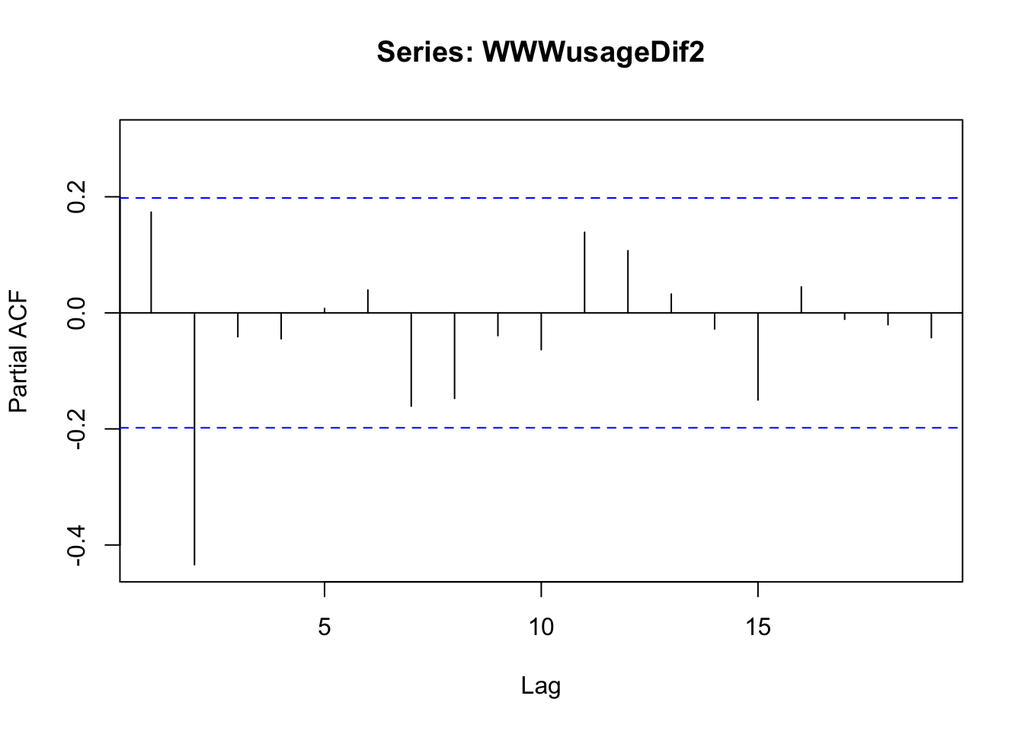

```r
Pacf(WWWusageDif2)
```

Let’s start with AR(1) and an MA(1); p = 1, q = 1 initially.

##### 5.Fit an initial ARIMA model.

```r
fit121 = Arima(WWWusageDif2, c(1, 2, 1))
summary(fit121)
```

```
## Series: WWWusageDif2
## ARIMA(1,2,1)
##
## Coefficients:
##           ar1      ma1
##       -0.1358  -1.0000
## s.e.   0.1022   0.0263
##
## sigma^2 estimated as 21.19:  log likelihood=-285.2
## AIC=576.4   AICc=576.66   BIC=584.1
##
## Training set error measures:
##                     ME    RMSE      MAE MPE MAPE      MASE       ACF1
## Training set 0.2614019 4.55563 3.615365 NaN  Inf 0.9768534 -0.4972663
```

```r
sig(fit121)
```

```
##   ar1   ma1
## 0.184 0.000
```

```r
#Here the AR term is not significant, I will move on to p = 2
```

##### 6.Follow the process of overfitting the initial ARIMA model you fit in part 5. At each step, examine the Wald test statistics for the coefficient estimates. (NB: If you seem to have already overfit your model, try taking away terms by reversing the overfitting process).

```r
fit221 = Arima(WWWusageDif2, order = c(2, 2, 1))
summary(fit221)
```

```
## Series: WWWusageDif2
## ARIMA(2,2,1)
##
## Coefficients:
##           ar1      ar2      ma1
##       -0.2191  -0.4951  -1.0000
## s.e.   0.0898   0.0893   0.0266
##
## sigma^2 estimated as 15.91:  log likelihood=-272.14
## AIC=552.29   AICc=552.73   BIC=562.55
##
## Training set error measures:
##                     ME    RMSE     MAE MPE MAPE     MASE      ACF1
## Training set 0.1990229 3.94789 3.14387 NaN  Inf 0.849458 -0.121136
```

```r
sig(fit221) # here the coefficients are significant.  I will try increase the q value to 2 to see the impact
```

```
##   ar1   ar2   ma1
## 0.015 0.000 0.000
```

```r
fit222 = Arima(WWWusageDif2, order = c(2, 2, 2))
summary(fit222)
```

```
## Series: WWWusageDif2
## ARIMA(2,2,2)
##
## Coefficients:
##          ar1      ar2      ma1     ma2
##       0.2735  -0.4255  -1.9986  0.9995
## s.e.  0.0940   0.0928   0.1083  0.1083
##
## sigma^2 estimated as 10.42:  log likelihood=-256.56
## AIC=523.13   AICc=523.79   BIC=535.95
##
## Training set error measures:
##                     ME     RMSE      MAE MPE MAPE      MASE        ACF1
## Training set 0.3695345 3.195213 2.520869 NaN  Inf 0.6811261 -0.01647456
```

```r
sig(fit222) #by adding an additional ma term the significance of the first ar term is increased.  I will work with this model.
```

```
##   ar1   ar2   ma1   ma2
## 0.004 0.000 0.000 0.000
```

##### 7.Evaluate the family of models you created in part 6 and select the best (examine the AIC, BIC, and RMSE).

```r
AIC(fit121, fit221, fit222)
```

```
##        df      AIC
## fit121  3 576.4021
## fit221  4 552.2886
## fit222  5 523.1268
```

```r
BIC(fit121, fit221, fit222)
```

```
##        df      BIC
## fit121  3 584.0951
## fit221  4 562.5459
## fit222  5 535.9486
```

```r
summary(fit121) #RMSE 4.56
```

```
## Series: WWWusageDif2
## ARIMA(1,2,1)
##
## Coefficients:
##           ar1      ma1
##       -0.1358  -1.0000
## s.e.   0.1022   0.0263
##
## sigma^2 estimated as 21.19:  log likelihood=-285.2
## AIC=576.4   AICc=576.66   BIC=584.1
##
## Training set error measures:
##                     ME    RMSE      MAE MPE MAPE      MASE       ACF1
## Training set 0.2614019 4.55563 3.615365 NaN  Inf 0.9768534 -0.4972663
```

```r
summary(fit221) #RMSE 3.95
```

```
## Series: WWWusageDif2
## ARIMA(2,2,1)
##
## Coefficients:
##           ar1      ar2      ma1
##       -0.2191  -0.4951  -1.0000
## s.e.   0.0898   0.0893   0.0266
##
## sigma^2 estimated as 15.91:  log likelihood=-272.14
## AIC=552.29   AICc=552.73   BIC=562.55
##
## Training set error measures:
##                     ME    RMSE     MAE MPE MAPE     MASE      ACF1
## Training set 0.1990229 3.94789 3.14387 NaN  Inf 0.849458 -0.121136
```

```r
summary(fit222) #RMSE 3.20
```

```
## Series: WWWusageDif2
## ARIMA(2,2,2)
##
## Coefficients:
##          ar1      ar2      ma1     ma2
##       0.2735  -0.4255  -1.9986  0.9995
## s.e.  0.0940   0.0928   0.1083  0.1083
##
## sigma^2 estimated as 10.42:  log likelihood=-256.56
## AIC=523.13   AICc=523.79   BIC=535.95
##
## Training set error measures:
##                     ME     RMSE      MAE MPE MAPE      MASE        ACF1
## Training set 0.3695345 3.195213 2.520869 NaN  Inf 0.6811261 -0.01647456
```

fit222 has the lowest values for AIC, BIC and RMSE, we will proceed with this model.

##### 8.Loosely interpret the coefficient estimates of the model you selected in part 7.

```r
fit222$coef
```

```
##        ar1        ar2        ma1        ma2
##  0.2735330 -0.4255239 -1.9985759  0.9995277
```

##### 9. Perform diagnostic tests for the best model by assessing:

###### a. The constant variance assumption (graphically).

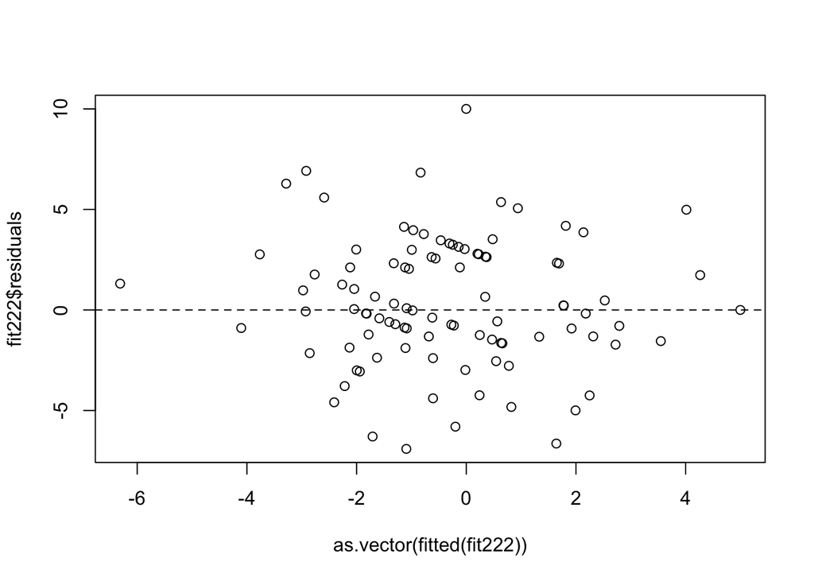

```r
plot(as.vector(fitted(fit222)), fit222$residuals)
abline(h = 0, lty = 2)
```

Maybe a violation of constant variance, not clear (seems that resuduals are centered around the middle.

###### b. The normality assumption (graphically).

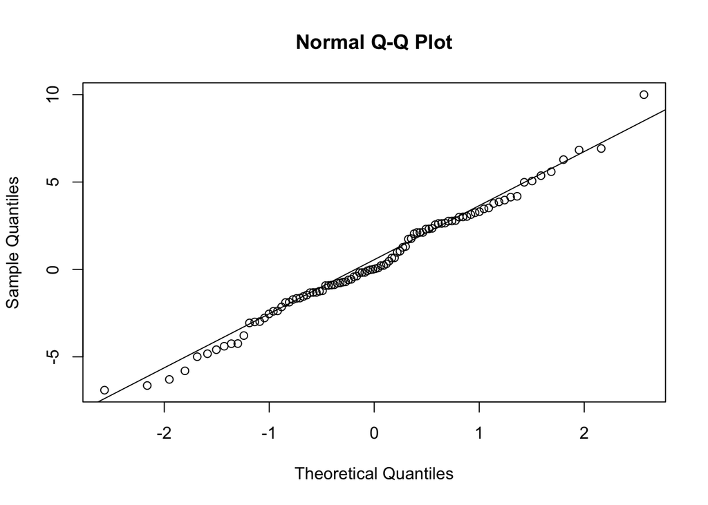

```r
qqnorm(fit222$residuals)
qqline(fit222$residuals)
```

Does not appear to be a violation of normality

###### c. The independence assumption (graphically & statistically).

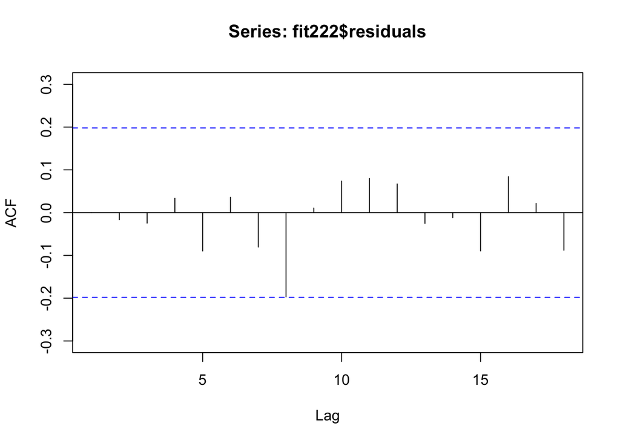

```r
Acf(fit222$residuals) #nothing significant here, independence is okay
```

```r
Box.test(fit222$residuals, type = "Ljung-Box") #p-value is insignificant therefore we can retain the null hypothesis that the correlations among the residuals are zero, therefore the model is sufficient.
```

```
##
##  Box-Ljung test
##
## data:  fit222$residuals
## X-squared = 0.011702, df = 1, p-value = 0.9139
```

##### 10. Forecast the next few observations and display this graphically.

```r
new.values <- forecast(fit222, 10, level = c(60, 80, 95))
new.values
```

```
##     Point Forecast     Lo 60    Hi 60     Lo 80    Hi 80     Lo 95
## 101    1.319120874 -1.426564 4.064805 -2.861781 5.500023 -5.075018
## 102   -0.572708710 -3.435337 2.289920 -4.931684 3.786267 -7.239186
## 103   -0.803947202 -3.798690 2.190796 -5.364095 3.756201 -7.778091
## 104   -0.065670945 -3.104897 2.973555 -4.693554 4.562212 -7.143408
## 105    0.231178345 -2.822712 3.285069 -4.419035 4.881392 -6.880710
## 106   -0.005268885 -3.081792 3.071254 -4.689946 4.679408 -7.169864
## 107   -0.199752562 -3.276175 2.876670 -4.884276 4.484771 -7.364113
## 108   -0.155827409 -3.232577 2.920922 -4.840848 4.529193 -7.320948
## 109   -0.064546080 -3.141121 3.012029 -4.749301 4.620209 -7.229261
## 110   -0.061759931 -3.140345 3.016825 -4.749576 4.626056 -7.231156
##        Hi 95
## 101 7.713259
## 102 6.093769
## 103 6.170197
## 104 7.012066
## 105 7.343066
## 106 7.159326
## 107 6.964608
## 108 7.009293
## 109 7.100169
## 110 7.107636
```

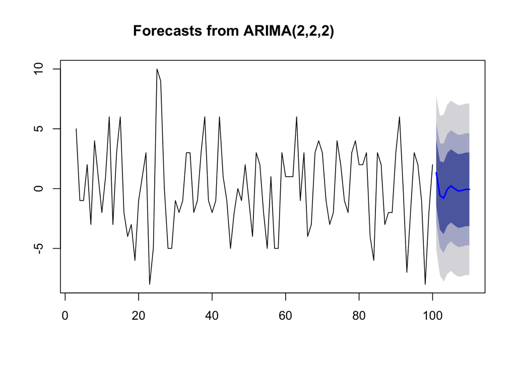

```r
plot(new.values)
```

##### 11. How will server traffic change over the next few minutes?

There appears to be a slight drop and tehn stables out after a few observations.

#### The nhtemp dataset; this dataset describes the average yearly temperatures (°F) in New Haven, Connecticut.

```r
nhtemp <- nhtemp
```

##### 1.Plot the original time series

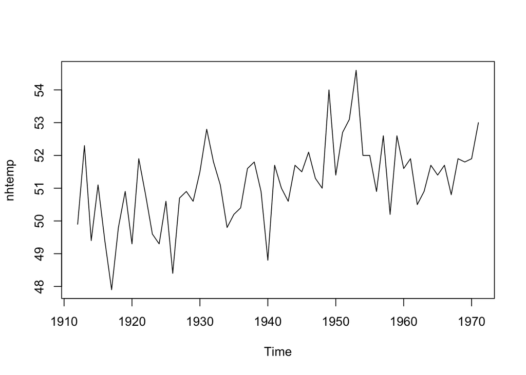

```r
plot(nhtemp)
```

##### 2.Determine the estimated number of differences necessary to make the time series stationary. If non-stationary, plot the differenced time series.

```r
ndiffs(nhtemp)
```

```
## [1] 1
```

```r
nhtempDif <- diff(nhtemp, differences = 1)
ndiffs(nhtempDif)
```

```
## [1] 0
```

d = 1 differenced ndiff = 0

##### 3.Run the Augmented Dicky-Fuller test and interpret the results. If necessary, return to part 2.

```r
adf.test(nhtempDif)
```

```
##
##  Augmented Dickey-Fuller Test
##
## data:  nhtempDif
## Dickey-Fuller = -4.6366, Lag order = 3, p-value = 0.01
## alternative hypothesis: stationary
```

The p value for the differenced model is significant, we can move forward with this model.

##### 4.Plot the autocorrelation and partial autocorrelation functions to determine intial values of p & q.

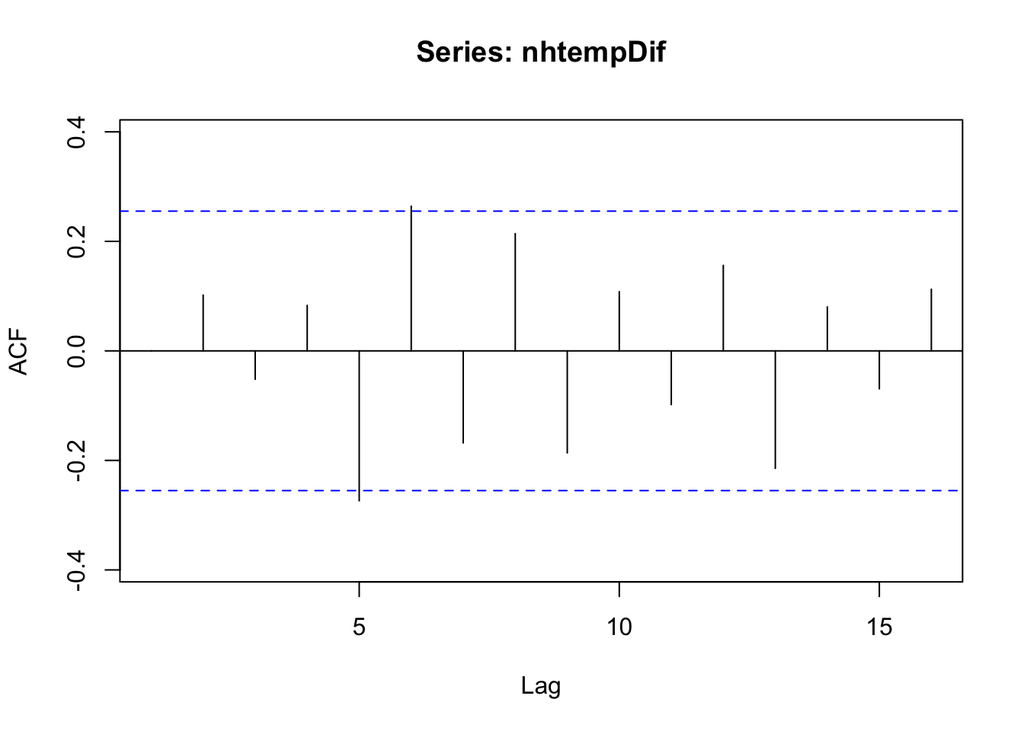

```r
Acf(nhtempDif)
```

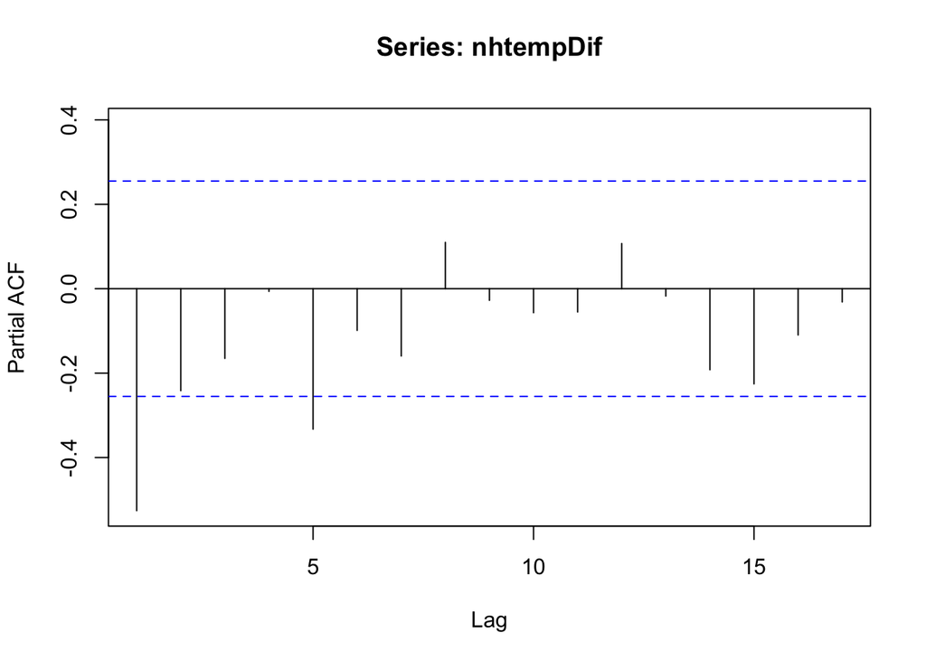

```r
Pacf(nhtempDif)
```

Let’s start with AR(1) and an MA(0); p = 1, q = 0 initially.

##### 5.Fit an initial ARIMA model.

```r
fit110 = Arima(nhtempDif, c(1, 1, 0))
summary(fit110)
```

```
## Series: nhtempDif
## ARIMA(1,1,0)
##
## Coefficients:
##           ar1
##       -0.7255
## s.e.   0.0935
##
## sigma^2 estimated as 3.187:  log likelihood=-116.29
## AIC=236.57   AICc=236.79   BIC=240.69
##
## Training set error measures:
##                       ME    RMSE      MAE  MPE MAPE      MASE       ACF1
## Training set -0.02226552 1.77004 1.414989 -Inf  Inf 0.7008484 -0.3954794
```

```r
sig(fit110)
```

```
## ar1
##   0
```

The ar1 term here is significant, therefore I will use this model going forward.